# Testing for AND/OR circuits in GPT2-Small

# Background

- Hypothesis: another explanation for discrepancies is that integrated gradients may flag latent components (which only activate in AND/OR circuits). For example, a later attention head may depend on an earlier one.
- Method: we run activation patching from corrupt to clean, and from clean to corrupt. We also run integrated gradients from corrupt to clean, and from clean to corrupt. AND/OR components will be flagged in integrated gradients in both directions, but only flagged in one direction for patching.
  - Clean→corrupt should pick up OR circuits, Corrupt→clean should pick up AND circuits.
  - AP asymmetry score: difference between AP scores in two directions, normalised by max score.
  - IG asymmetry score: difference between IG scores in two directions, normalised by max score.
  - AND/OR candidates should have low IG asymmetry and high AP asymmetry.
- Implications: if true, we could use IG to detect results which would have required two activation patching passes in different directions.

```python
%load_ext autoreload
%autoreload 2
```

```python
import torch
import pandas as pd
import numpy as np

from functools import partial
from typing import Optional

from transformer_lens.utils import get_act_name, get_device
from transformer_lens import ActivationCache, HookedTransformer, HookedTransformerConfig
from transformer_lens.hook_points import HookPoint

import seaborn as sns
import matplotlib.pyplot as plt

from utils import Task, TaskDataset, logit_diff_metric, run_from_layer_fn, plot_attn_comparison, plot_correlation
from attribution_methods import integrated_gradients, activation_patching
from captum.attr import LayerIntegratedGradients
```

# AND toy model

```python
import torch
import torch.nn as nn
import torch.optim as optim

# Define a simple feedforward neural network
class ANDORNet(nn.Module):
    def __init__(self):
        super(ANDORNet, self).__init__()
        self.model = nn.Sequential(
            nn.Linear(2, 2),
            nn.ReLU(),
            nn.Linear(2, 1),
            nn.Sigmoid(),
        )

    def forward(self, x):
        return self.model(x)

    def run_with_cache(self, x):
        cache = {}

        # Hook function to save output
        def save_activation(name):
            def hook(module, input, output):
                cache[name] = output.detach()
            return hook

        # Register hooks
        handles = []
        for idx, layer in enumerate(self.model):
            handles.append(layer.register_forward_hook(save_activation(f"layer_{idx}")))

        # Run forward pass
        with torch.no_grad():
            output = self.forward(x)

        # Clean up hooks
        for handle in handles:
            handle.remove()

        return output, cache
```

```python
# Training data for AND logic gate
X = torch.tensor([[0., 0.],
                  [0., 1.],
                  [1., 0.],
                  [1., 1.]])

y = torch.tensor([[0.],
                  [0.],
                  [0.],
                  [1.]])


# Initialize the network, loss function and optimizer
and_model = ANDORNet()
criterion = nn.BCELoss()  # Binary Cross Entropy for binary classification
optimizer = optim.SGD(and_model.parameters(), lr=0.1)

# Training loop
with torch.enable_grad():
    for epoch in range(1000):
        shuffle_order = torch.randperm(X.size(0))
        shuffled_X = X[shuffle_order]
        shuffled_y = y[shuffle_order]

        optimizer.zero_grad()
        outputs = and_model(shuffled_X)
        loss = criterion(outputs, shuffled_y)
        loss.backward()
        optimizer.step()
        if epoch % 100 == 0:
            print(f"Epoch {epoch}, Loss: {loss.item():.4f}")

# Evaluate model
with torch.no_grad():
    preds = and_model(X)
    print("Predictions:")
    print(preds.round())  # Round predictions to get binary output
```

```
Epoch 0, Loss: 0.7413
Epoch 100, Loss: 0.5646
Epoch 200, Loss: 0.5624
Epoch 300, Loss: 0.5623
Epoch 400, Loss: 0.5623
Epoch 500, Loss: 0.5623
Epoch 600, Loss: 0.5623
Epoch 700, Loss: 0.5623
Epoch 800, Loss: 0.5623
Epoch 900, Loss: 0.5623
Predictions:
tensor([[0.],
        [0.],
        [0.],
        [0.]])
```

```python
clean_input = torch.tensor([[1., 1.]], requires_grad=True)
corrupt_input = torch.tensor([[0., 0.]], requires_grad=True)
positive_output, clean_cache = and_model.run_with_cache(clean_input)
negative_output, corrupt_cache = and_model.run_with_cache(corrupt_input)

print(positive_output, clean_cache)
print(negative_output, corrupt_cache)
```

```
tensor([[0.2500]]) {'layer_0': tensor([[-0.6052, -1.3244]]), 'layer_1': tensor([[0., 0.]]), 'layer_2': tensor([[-1.0986]]), 'layer_3': tensor([[0.2500]])}
tensor([[0.2500]]) {'layer_0': tensor([[-0.0308, -0.6679]]), 'layer_1': tensor([[0., 0.]]), 'layer_2': tensor([[-1.0986]]), 'layer_3': tensor([[0.2500]])}
```

```python
ig = LayerIntegratedGradients(and_model, and_model.model[0], multiply_by_inputs=True)
# Patch clean into corrupt
ig_and_attributions = ig.attribute(
    inputs=clean_input, baselines=corrupt_input, internal_batch_size=1
)
print(ig_and_attributions)

# Patch corrupt into clean
ig_and_attributions = ig.attribute(
    inputs=corrupt_input, baselines=clean_input, internal_batch_size=1
)
print(ig_and_attributions)
```

```
tensor([[0.4436, 0.5398]])
tensor([[-0.4436, -0.5398]])
```

```python
def toy_activation_patching(model: nn.Module, baseline_inputs, corrupt_inputs):
    """Attribution scores for neuron A and B in layer 0."""
    n_samples = baseline_inputs.size(0)
    baseline_diff = model(baseline_inputs) - model(corrupt_inputs)
    print(f"Patch {corrupt_inputs} into {baseline_inputs}")

    # Run the model, but patch in the given value at the target layer
    attributions = torch.zeros((n_samples, 2))
    for neuron_idx in range(2):
        # Corrupt specific neuron activations
        corrupted_value = baseline_inputs.clone()
        corrupted_value[:, neuron_idx] = corrupt_inputs[:, neuron_idx]

        patch_diff = model(baseline_inputs) - model(corrupted_value)
        attributions[:, neuron_idx] = patch_diff / baseline_diff

    return attributions

with torch.no_grad():
    # Patch clean into corrupt
    ap_and_clean_corrupt = toy_activation_patching(and_model, corrupt_input, clean_input)
    print(f"Clean->Corrupt: {ap_and_clean_corrupt}\n")
    # Patch corrupt into clean
    ap_and_corrupt_clean = toy_activation_patching(and_model, clean_input, corrupt_input)
    print("Corrupt->Clean", ap_and_corrupt_clean)
```

```
Patch tensor([[1., 1.]], requires_grad=True) into tensor([[0., 0.]], requires_grad=True)
Clean->Corrupt: tensor([[0.0117, 0.0116]])

Patch tensor([[0., 0.]], requires_grad=True) into tensor([[1., 1.]], requires_grad=True)
Corrupt->Clean tensor([[0.9884, 0.9883]])
```

In the example of the AND toy model, we can see that:

- IG attributes roughly even importance (0.5) to neurons A and B. This is correct and holds for gradients in both directions (order of clean/corrupt as input/baseline only affects sign).
- Activation patching from clean ([1, 1]) to corrupt ([0, 0]) suggests that both A and B have low attribution scores, because patching either A or B does not affect the output. Denoising fails to identify the circuit components.
- Activation patching from corrupt ([0, 0]) to clean ([1, 1]) suggests that both A and B have high attribution scores, because patching either A or B affects the output.

```python
import torch
import torch.nn as nn
import torch.optim as optim

# Training data for OR logic gate
X = torch.tensor([[0., 0.],
                  [0., 1.],
                  [1., 0.],
                  [1., 1.]])

y = torch.tensor([[0.],
                  [1.],
                  [1.],
                  [1.]])

# Initialize the model, loss function, and optimizer
or_model = ANDORNet()
criterion = nn.BCELoss()
optimizer = optim.SGD(or_model.parameters(), lr=0.1)

# Training loop
with torch.enable_grad():
    for epoch in range(3000):
        shuffle_order = torch.randperm(X.size(0))
        shuffled_X = X[shuffle_order]
        shuffled_y = y[shuffle_order]

        optimizer.zero_grad()
        outputs = or_model(shuffled_X)
        loss = criterion(outputs, shuffled_y)
        loss.backward()
        optimizer.step()
        if epoch % 100 == 0:
            print(f"Epoch {epoch}, Loss: {loss.item():.4f}")

# Evaluate
with torch.no_grad():
    preds = or_model(X)
    print("Predictions:")
    print(preds.round())
```

```
Epoch 0, Loss: 0.6846
Epoch 100, Loss: 0.2661
Epoch 200, Loss: 0.1278
Epoch 300, Loss: 0.0806
Epoch 400, Loss: 0.0564
Epoch 500, Loss: 0.0424
Epoch 600, Loss: 0.0336
Epoch 700, Loss: 0.0277
Epoch 800, Loss: 0.0234
Epoch 900, Loss: 0.0202
Epoch 1000, Loss: 0.0177
Epoch 1100, Loss: 0.0157
Epoch 1200, Loss: 0.0142
Epoch 1300, Loss: 0.0128
Epoch 1400, Loss: 0.0117
Epoch 1500, Loss: 0.0108
Epoch 1600, Loss: 0.0100
Epoch 1700, Loss: 0.0093
Epoch 1800, Loss: 0.0087
Epoch 1900, Loss: 0.0082
Epoch 2000, Loss: 0.0077
Epoch 2100, Loss: 0.0073
Epoch 2200, Loss: 0.0069
Epoch 2300, Loss: 0.0066
Epoch 2400, Loss: 0.0063
Epoch 2500, Loss: 0.0060
Epoch 2600, Loss: 0.0057
Epoch 2700, Loss: 0.0055
Epoch 2800, Loss: 0.0052
Epoch 2900, Loss: 0.0050
Predictions:
tensor([[0.],
        [1.],
        [1.],
        [1.]])
```

```python
clean_input = torch.tensor([[1., 1.]], requires_grad=True)
corrupt_input = torch.tensor([[0., 0.]], requires_grad=True)
positive_output, clean_cache = or_model.run_with_cache(clean_input)
negative_output, corrupt_cache = or_model.run_with_cache(corrupt_input)

print(positive_output, clean_cache)
print(negative_output, corrupt_cache)
```

```
tensor([[1.]]) {'layer_0': tensor([[5.1611, 1.2891]]), 'layer_1': tensor([[5.1611, 1.2891]]), 'layer_2': tensor([[16.9526]]), 'layer_3': tensor([[1.]])}
tensor([[0.0171]]) {'layer_0': tensor([[-0.0013, -0.0002]]), 'layer_1': tensor([[0., 0.]]), 'layer_2': tensor([[-4.0531]]), 'layer_3': tensor([[0.0171]])}
```

```python
ig_or = LayerIntegratedGradients(or_model, or_model.model[0], multiply_by_inputs=True)
# Patch clean into corrupt
ig_or_attributions = ig_or.attribute(
    inputs=clean_input, baselines=corrupt_input, internal_batch_size=1
)
print(ig_or_attributions)

# Patch corrupt into clean
ig_or_attributions = ig_or.attribute(
    inputs=corrupt_input, baselines=clean_input, internal_batch_size=1
)
print(ig_or_attributions)
```

```
tensor([[0.8867, 0.0963]])
tensor([[-0.8867, -0.0963]])
```

```python
with torch.no_grad():
    # Patch clean into corrupt
    ap_or_clean_corrupt = toy_activation_patching(or_model, corrupt_input, clean_input)
    print(f"Clean->Corrupt: {ap_or_clean_corrupt}\n")
    # Patch corrupt into clean
    ap_or_corrupt_clean = toy_activation_patching(or_model, clean_input, corrupt_input)
    print("Corrupt->Clean", ap_or_corrupt_clean)
```

```
Patch tensor([[1., 1.]], requires_grad=True) into tensor([[0., 0.]], requires_grad=True)
Clean->Corrupt: tensor([[0.9990, 0.9988]])

Patch tensor([[0., 0.]], requires_grad=True) into tensor([[1., 1.]], requires_grad=True)
Corrupt->Clean tensor([[0.0012, 0.0010]])
```

# AND/OR circuits in GPT2-small

```python
torch.set_grad_enabled(False)

device = get_device()
# device = torch.device("cpu")
model = HookedTransformer.from_pretrained("gpt2-small", device=device)

# Explicitly calculate and expose the result for each attention head
model.set_use_attn_result(True)
model.set_use_hook_mlp_in(True)
```

```
Loaded pretrained model gpt2-small into HookedTransformer
```

```python
ioi_dataset = TaskDataset(Task.IOI)
ioi_dataloader = ioi_dataset.to_dataloader(batch_size=100)

clean_input, corrupted_input, labels = next(iter(ioi_dataloader))

clean_tokens = model.to_tokens(clean_input)
corrupted_tokens = model.to_tokens(corrupted_input)

clean_logits, clean_cache = model.run_with_cache(clean_tokens)
clean_logit_diff = logit_diff_metric(clean_logits, labels)
print(f"Clean logit difference: {clean_logit_diff}")

corrupted_logits, corrupted_cache = model.run_with_cache(corrupted_tokens)
corrupted_logit_diff = logit_diff_metric(corrupted_logits, labels)
print(f"Corrupted logit difference: {corrupted_logit_diff}")
```

```
Clean logit difference: tensor([-0.0307, -0.9269, -0.4937,  2.2320,  0.6754,  4.0447, -0.1785,  1.1947,
         1.1514,  1.7507,  0.1791,  4.2971,  2.9955, -0.7016, -2.1907, -3.5684,
        -4.4879, -1.2934, -3.8906, -0.6969, -0.8222,  0.0708,  0.2167,  4.4769,
         1.0375, -1.2644,  0.9309,  2.8114,  0.9975,  2.4103,  2.6244,  0.0125,
        -0.8472, -0.6130, -1.1623, -0.5109,  3.0073,  0.6154, -1.1229,  0.2680,
        -2.7379,  5.2855,  2.5019,  0.3219, -1.3112,  1.2942, -2.1428,  3.1053,
         1.6090,  3.1023,  1.8912,  0.4089,  4.0511,  2.5005,  3.5176, -1.5472,
         2.2213, -0.8523,  0.6682,  0.4244,  0.8053,  3.2905,  0.7295,  0.9946,
        -3.6073, -2.2671,  1.7894, -0.6390,  0.6320, -1.5326,  1.3206, -0.1224,
         0.1692,  1.9326,  3.1771,  1.1320, -0.0876,  3.1172,  2.3856,  3.2836,
        -2.0859,  3.6953,  2.8493, -2.4261,  1.1299,  0.1732, -1.4748, -2.1046,
        -0.6516, -0.6167,  0.0277, -1.7128,  0.6374,  2.6353, -1.4080,  3.2583,
         0.6919, -2.4436,  0.6666,  2.5258], device='cuda:0')
Corrupted logit difference: tensor([-3.8746e-02, -9.4513e-01, -5.1027e-01,  2.2153e+00,  6.2990e-01,
        -3.2074e+00, -1.8231e-01,  1.1766e+00, -3.0072e+00,  1.7392e+00,
         1.4938e-01,  2.5879e-01, -4.2863e+00, -7.1594e-01, -2.2568e+00,
        -3.5882e+00, -4.4825e+00, -1.3015e+00, -3.9175e+00, -7.0902e-01,
        -8.1898e-01,  4.9942e-02,  2.0002e-01,  4.4623e+00,  1.0164e+00,
        -1.2665e+00,  9.0841e-01, -4.5392e+00,  9.8613e-01,  2.4149e+00,
         2.6026e+00, -9.6662e-03, -8.9293e-01, -6.2356e-01, -1.1595e+00,
        -5.1318e-01, -1.1410e+00,  6.0697e-01, -1.1723e+00,  2.4156e-01,
        -2.7512e+00, -1.6695e+00,  2.4944e+00,  3.2915e-01, -1.3232e+00,
         1.2809e+00, -2.1493e+00,  3.1009e+00,  1.6058e+00, -2.0700e+00,
        -1.9341e+00,  3.9242e-01, -1.7774e+00,  2.4945e+00, -4.5008e+00,
        -1.6102e+00,  2.2123e+00, -8.6050e-01,  6.3914e-01,  4.0987e-01,
         7.8476e-01, -3.1501e+00,  7.3348e-01,  9.7457e-01, -3.6393e+00,
        -2.2872e+00,  1.7992e+00, -6.3969e-01, -2.1137e+00, -1.5704e+00,
         1.2943e+00, -1.2390e-01,  1.5703e-01,  1.9095e+00,  3.1132e+00,
         1.1251e+00, -1.0500e-01,  3.1100e+00,  2.3432e+00, -2.7600e+00,
        -2.1219e+00, -3.6873e+00, -4.4972e+00, -2.4419e+00,  1.1330e+00,
         1.4468e-01, -1.4990e+00, -2.1135e+00, -6.9057e-01, -6.2553e-01,
         1.6036e-03, -1.7046e+00,  6.0108e-01, -4.6585e+00, -1.4097e+00,
         3.2455e+00,  6.7000e-01, -2.4674e+00,  6.4137e-01, -4.3624e+00],
       device='cuda:0')
```

```python
# Patch from clean to corrupt

ig_clean_corrupt_mlp, ig_clean_corrupt_attn = integrated_gradients(model, clean_tokens, clean_cache, corrupted_cache, logit_diff_metric, labels)

torch.save(ig_clean_corrupt_mlp, "saved_results/ig_clean_corrupt_mlp.pt")
torch.save(ig_clean_corrupt_attn, "saved_results/ig_clean_corrupt_attn.pt")
```

[output not shown]

[output cut: 484 more lines]

[output not shown]

```python
ap_clean_corrupt_mlp, ap_clean_corrupt_attn = activation_patching(model, clean_tokens, clean_cache, clean_logit_diff, corrupted_cache, corrupted_logit_diff, logit_diff_metric, labels)

torch.save(ap_clean_corrupt_mlp, "saved_results/ap_clean_corrupt_mlp.pt")
torch.save(ap_clean_corrupt_attn, "saved_results/ap_clean_corrupt_attn.pt")
```

```
Activation patching on attention heads in layer 0
Activation patching on MLP in layer 0
Activation patching on attention heads in layer 1
Activation patching on MLP in layer 1
Activation patching on attention heads in layer 2
Activation patching on MLP in layer 2
Activation patching on attention heads in layer 3
Activation patching on MLP in layer 3
Activation patching on attention heads in layer 4
Activation patching on MLP in layer 4
Activation patching on attention heads in layer 5
Activation patching on MLP in layer 5
Activation patching on attention heads in layer 6
Activation patching on MLP in layer 6
Activation patching on attention heads in layer 7
Activation patching on MLP in layer 7
Activation patching on attention heads in layer 8
Activation patching on MLP in layer 8
Activation patching on attention heads in layer 9
Activation patching on MLP in layer 9
Activation patching on attention heads in layer 10
Activation patching on MLP in layer 10
Activation patching on attention heads in layer 11
Activation patching on MLP in layer 11
```

```python
# Patch from corrupt to clean

ig_corrupt_clean_mlp, ig_corrupt_clean_attn = integrated_gradients(model, corrupted_tokens, corrupted_cache, clean_cache, logit_diff_metric, labels)

torch.save(ig_corrupt_clean_mlp, "saved_results/ig_corrupt_clean_mlp.pt")
torch.save(ig_corrupt_clean_attn, "saved_results/ig_corrupt_clean_attn.pt")
```

[output not shown]

[output cut: 12 more lines]

[output not shown]

```python
ap_corrupt_clean_mlp, ap_corrupt_clean_attn = activation_patching(model, corrupted_tokens, corrupted_cache, corrupted_logit_diff, clean_cache, clean_logit_diff, logit_diff_metric, labels)

torch.save(ap_corrupt_clean_mlp, "saved_results/ap_corrupt_clean_mlp.pt")
torch.save(ap_corrupt_clean_attn, "saved_results/ap_corrupt_clean_attn.pt")
```

```python
ig_corrupt_clean_mlp = torch.load("saved_results/ig_corrupt_clean_mlp.pt")
ap_corrupt_clean_mlp = torch.load("saved_results/ap_corrupt_clean_mlp.pt")

ig_corrupt_clean_attn = torch.load("saved_results/ig_corrupt_clean_attn.pt")
ap_corrupt_clean_attn = torch.load("saved_results/ap_corrupt_clean_attn.pt")

ig_clean_corrupt_mlp = torch.load("saved_results/ig_clean_corrupt_mlp.pt")
ap_clean_corrupt_mlp = torch.load("saved_results/ap_clean_corrupt_mlp.pt")

ig_clean_corrupt_attn = torch.load("saved_results/ig_clean_corrupt_attn.pt")
ap_clean_corrupt_attn = torch.load("saved_results/ap_clean_corrupt_attn.pt")
```

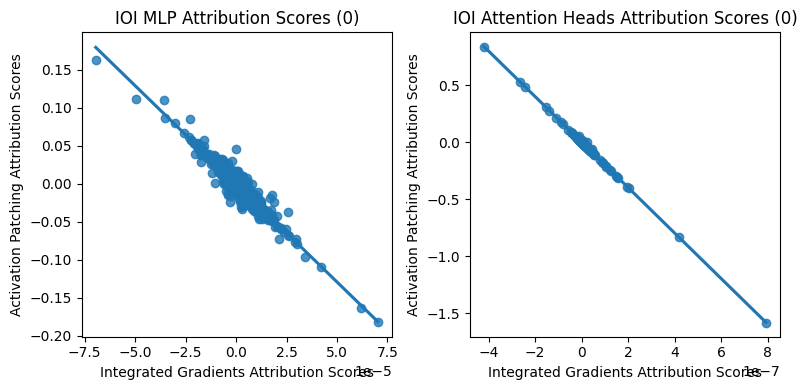

```
Correlation coefficient for neurons: -0.9813482457049195
Correlation coefficient for attention heads: -0.9994609848935359
```

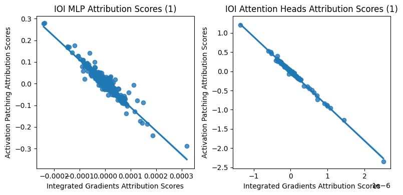

```
Correlation coefficient for neurons: -0.9675319186472084
Correlation coefficient for attention heads: -0.9980831409600232
```

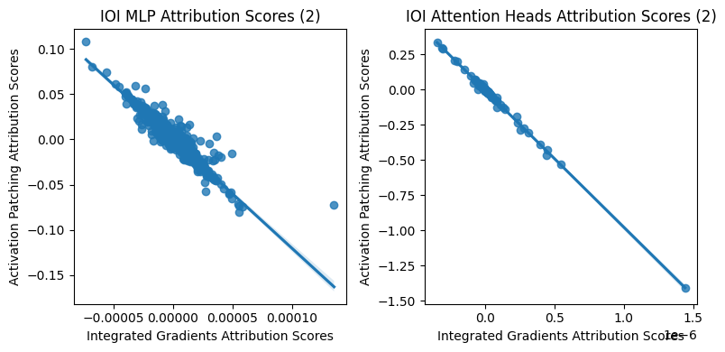

```
Correlation coefficient for neurons: -0.9675847825906044
Correlation coefficient for attention heads: -0.9983263102514046
```

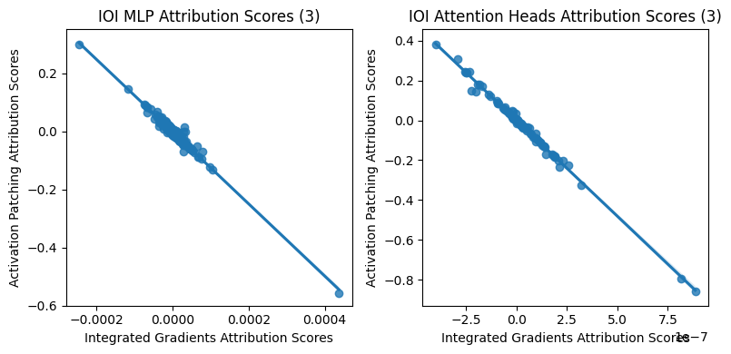

```
Correlation coefficient for neurons: -0.9870402073504491
Correlation coefficient for attention heads: -0.9970077754914994
```

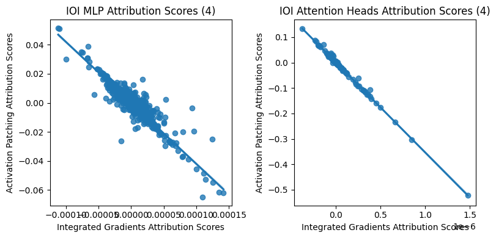

```
Correlation coefficient for neurons: -0.9570662046346103
Correlation coefficient for attention heads: -0.9975435216644236
```

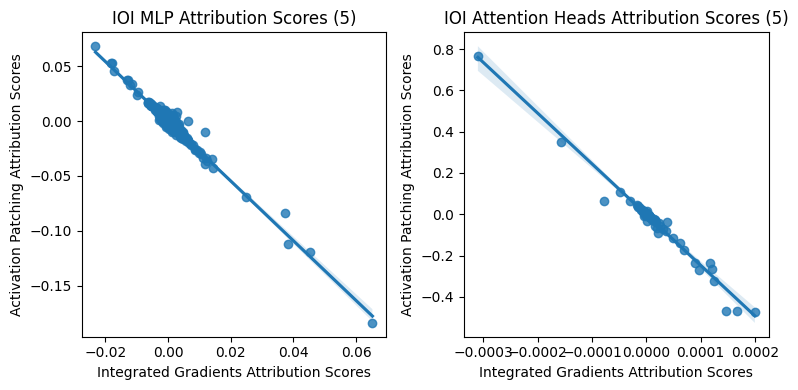

```
Correlation coefficient for neurons: -0.9779156123367726
Correlation coefficient for attention heads: -0.9872613656376347
```

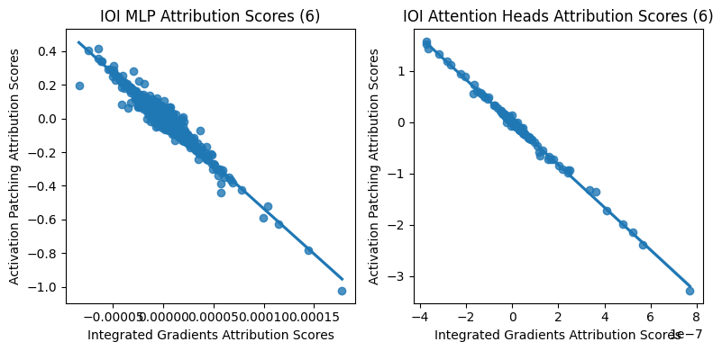

```
Correlation coefficient for neurons: -0.9823372472700865
Correlation coefficient for attention heads: -0.9981760858482338
```

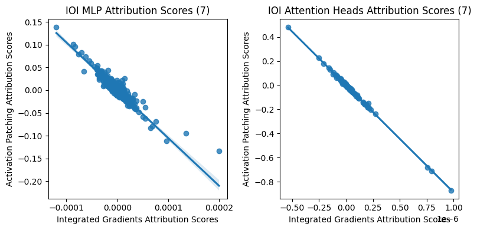

```
Correlation coefficient for neurons: -0.9627979719821647
Correlation coefficient for attention heads: -0.9992962580616394
```

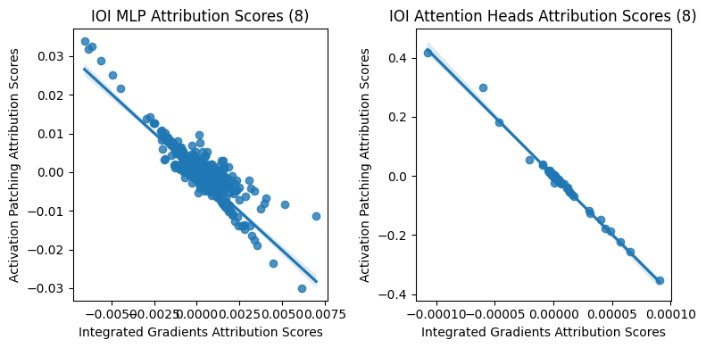

```
Correlation coefficient for neurons: -0.9023718010091047
Correlation coefficient for attention heads: -0.9957858326333561
```

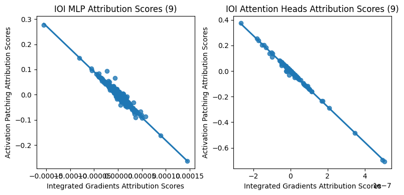

```
Correlation coefficient for neurons: -0.9880998197670189
Correlation coefficient for attention heads: -0.998408806692944
```

```python
plot_correlation(ig_corrupt_clean_mlp, ap_corrupt_clean_mlp, ig_corrupt_clean_attn, ap_corrupt_clean_attn, Task.IOI)
```

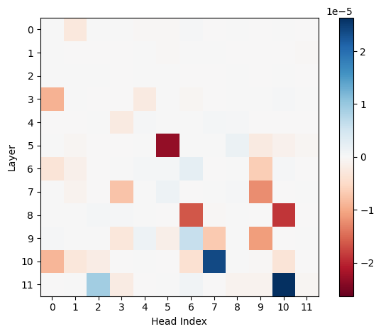

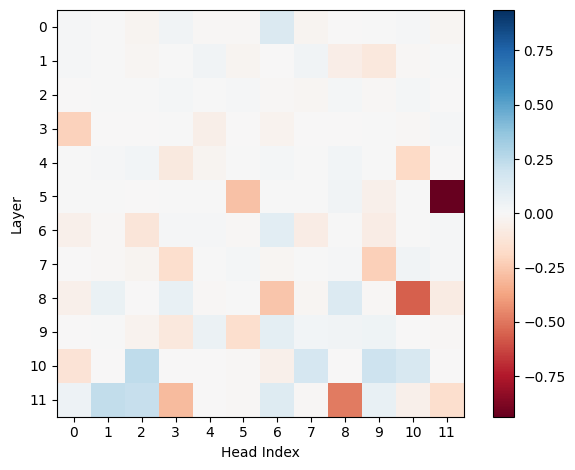

```python
from utils import plot_attn

avg_ig_clean_corrupt_mlp = ig_clean_corrupt_mlp.mean(dim=0, keepdim=True)
avg_ig_corrupt_clean_mlp = ig_corrupt_clean_mlp.mean(dim=0, keepdim=True)

avg_ap_clean_corrupt_mlp = ap_clean_corrupt_mlp.mean(dim=0, keepdim=True)
avg_ap_corrupt_clean_mlp = ap_corrupt_clean_mlp.mean(dim=0, keepdim=True)

avg_ig_clean_corrupt_attn = ig_clean_corrupt_attn.mean(dim=0, keepdim=True)
avg_ig_corrupt_clean_attn = ig_corrupt_clean_attn.mean(dim=0, keepdim=True)

avg_ap_clean_corrupt_attn = ap_clean_corrupt_attn.mean(dim=0, keepdim=True)
avg_ap_corrupt_clean_attn = ap_corrupt_clean_attn.mean(dim=0, keepdim=True)

plot_attn(avg_ig_clean_corrupt_attn[0], model)
plot_attn(avg_ap_clean_corrupt_attn[0], model)
```

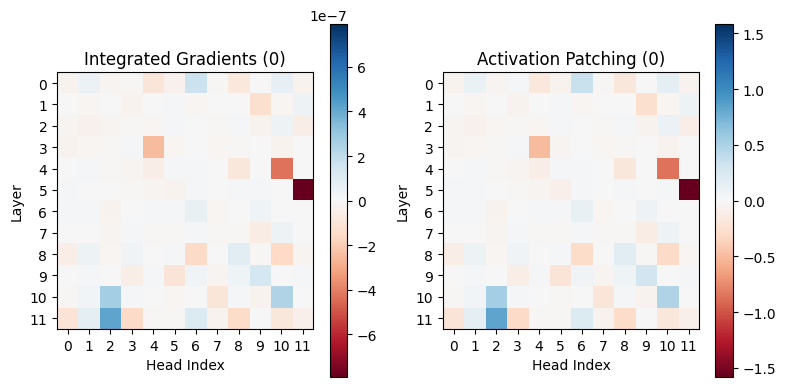

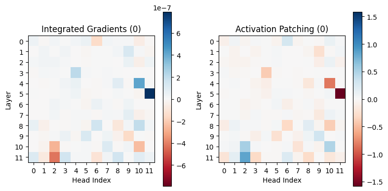

```python
# Sanity check: IG approximates AP in both directions of patching, although corrupt->clean for IG seems to be the opposite signage

plot_attn_comparison(ig_clean_corrupt_attn[0].unsqueeze(0), ap_clean_corrupt_attn[0].unsqueeze(0), Task.IOI, model)
plot_attn_comparison(ig_corrupt_clean_attn[0].unsqueeze(0), ap_corrupt_clean_attn[0].unsqueeze(0), Task.IOI, model)
```

## Mean attribution scores

```python
def asymmetry_score(corrupt_clean: torch.Tensor, clean_corrupt: torch.Tensor, is_ig: bool):
    assert corrupt_clean.shape == clean_corrupt.shape, \
        f"Cannot calculate asymmetry between matrices of different shapes, {corrupt_clean.shape} and {clean_corrupt.shape}"

    if is_ig:
        max_scores = torch.amax((clean_corrupt + corrupt_clean), dim=(1,2), keepdim=True)
        # Expect opposite directions to cancel out attribution scores
        print((corrupt_clean + clean_corrupt).shape, max_scores.shape)
        return torch.div((corrupt_clean + clean_corrupt), max_scores)

    max_scores = torch.amax((corrupt_clean - clean_corrupt), dim=(1,2), keepdim=True)
    return torch.div((corrupt_clean - clean_corrupt), max_scores)

ig_mlp_asymmetry = asymmetry_score(avg_ig_corrupt_clean_mlp, avg_ig_clean_corrupt_mlp, is_ig=True)
ig_attn_asymmetry = asymmetry_score(avg_ig_corrupt_clean_attn, avg_ig_clean_corrupt_attn, is_ig=True)

# The only requirement for an AND/OR circuit is high AP asymmetry
ap_mlp_asymmetry = asymmetry_score(avg_ap_corrupt_clean_mlp, avg_ap_clean_corrupt_mlp, is_ig=False)
ap_attn_asymmetry = asymmetry_score(avg_ap_corrupt_clean_attn, avg_ap_clean_corrupt_attn, is_ig=False)
```

```
torch.Size([1, 12, 3072]) torch.Size([1, 1, 1])
torch.Size([1, 12, 12]) torch.Size([1, 1, 1])
```

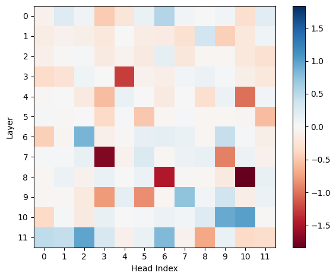

```python
from utils import plot_attn

plot_attn(ap_attn_asymmetry[0], model)
```

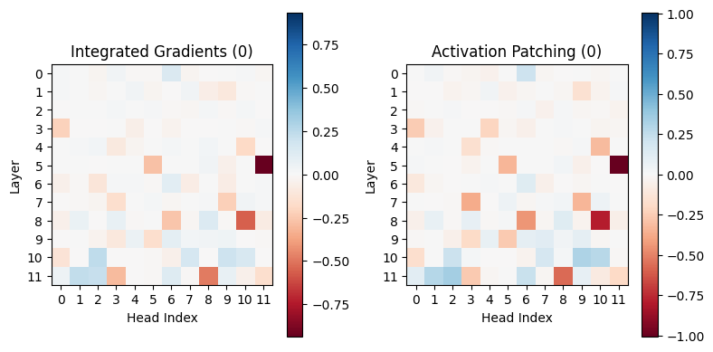

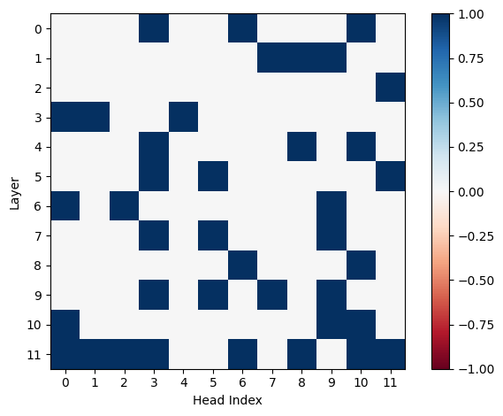

```python
plot_attn_comparison(avg_ap_clean_corrupt_attn, avg_ap_corrupt_clean_attn, Task.IOI, model)

high_ap_asymmetry = ap_attn_asymmetry.abs() > 0.25
plot_attn(high_ap_asymmetry[0].int(), model)
```

The matrix above indicates attention components which are AP asymmetric (i.e. different attribution scores for clean->corrupt and corrupt->clean patching). These components are possibly involved in AND/OR circuits.

## Individual example

```python
ig_mlp_asymmetry = asymmetry_score(ig_corrupt_clean_mlp[0].unsqueeze(0), ig_clean_corrupt_mlp[0].unsqueeze(0), is_ig=True)
ig_attn_asymmetry = asymmetry_score(ig_corrupt_clean_attn[0].unsqueeze(0), ig_clean_corrupt_attn[0].unsqueeze(0), is_ig=True)

# The only requirement for an AND/OR circuit is high AP asymmetry
ap_mlp_asymmetry = asymmetry_score(ap_corrupt_clean_mlp[0].unsqueeze(0), ap_clean_corrupt_mlp[0].unsqueeze(0), is_ig=False)
ap_attn_asymmetry = asymmetry_score(ap_corrupt_clean_attn[0].unsqueeze(0), ap_clean_corrupt_attn[0].unsqueeze(0), is_ig=False)
```

```
torch.Size([1, 12, 3072]) torch.Size([1, 1, 1])
torch.Size([1, 12, 12]) torch.Size([1, 1, 1])
```

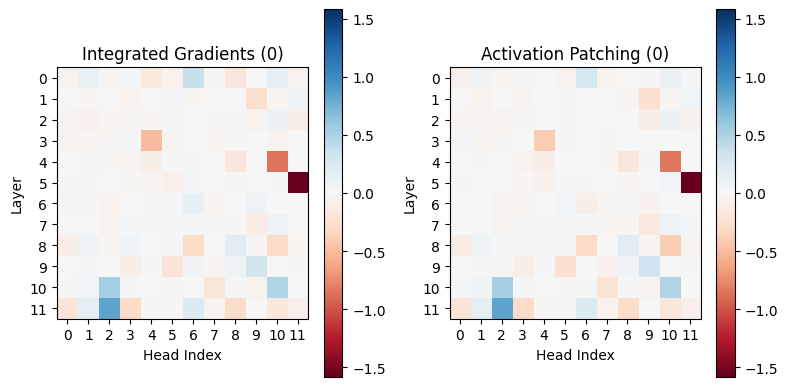

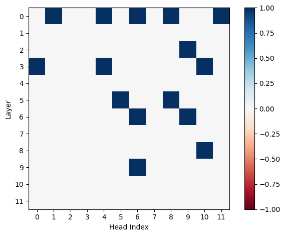

```python
plot_attn_comparison(ap_clean_corrupt_attn[0].unsqueeze(0), ap_corrupt_clean_attn[0].unsqueeze(0), Task.IOI, model)

individual_high_ap_asymmetry = ap_attn_asymmetry[0].abs() > 0.25
plot_attn(individual_high_ap_asymmetry.int(), model)
```

# Does IG alone highlight AND/OR components?

## Means

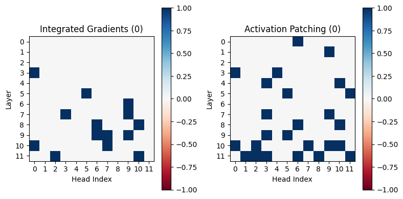

```python
mean_attn_ig = avg_ig_corrupt_clean_attn.mean()
std_attn_ig = avg_ig_corrupt_clean_attn.std()

ig_significant = avg_ig_corrupt_clean_attn.abs() > (mean_attn_ig + std_attn_ig)
ig_attn_indices = ig_significant.nonzero()

mean_attn_ap = avg_ap_corrupt_clean_attn.mean()
std_attn_ap = avg_ap_corrupt_clean_attn.std()

ap_significant = avg_ap_corrupt_clean_attn.abs() > (mean_attn_ap + std_attn_ap)
ap_attn_indices = ap_significant.nonzero()

plot_attn_comparison(ig_significant.int(), ap_significant.int(), Task.IOI, model)
```

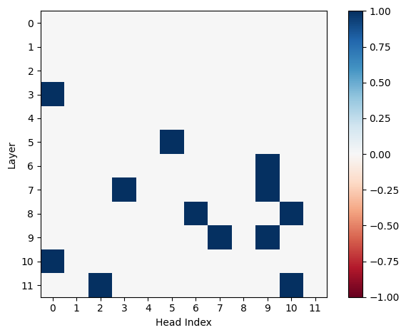

```python
# Get IG highlighted components which also have high AP asymmetry
ig_indicated_and_or = high_ap_asymmetry & ig_significant

plot_attn(ig_indicated_and_or[0].int(), model)
```

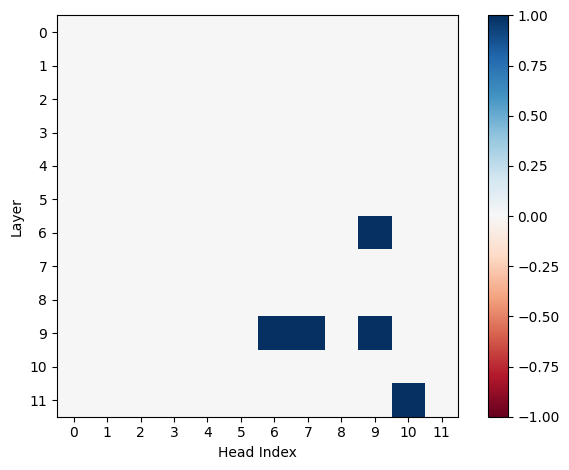

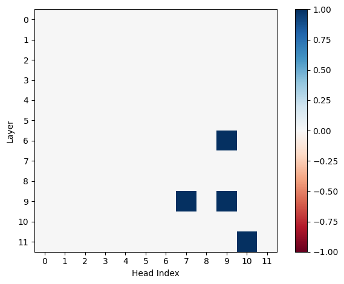

```python
ig_exclusive = ig_significant & ~ap_significant
plot_attn(ig_exclusive[0].int(), model)
# IG-exclusive components which highlight AND/OR
plot_attn((high_ap_asymmetry & ig_exclusive)[0].int(), model)
```

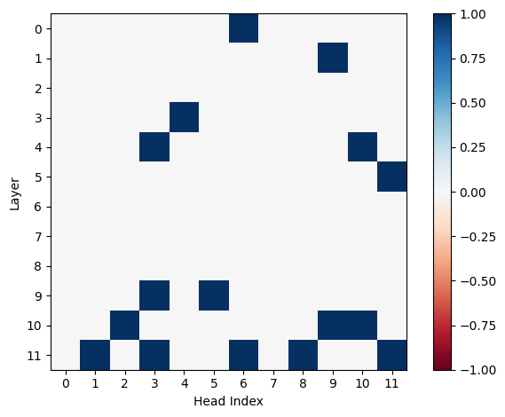

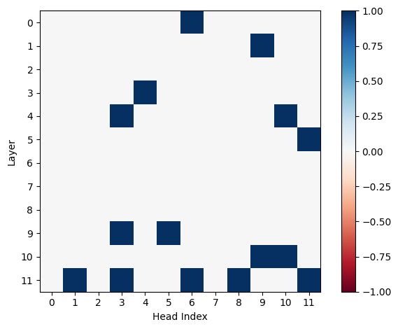

```python
ap_exclusive = ap_significant & ~ig_significant
plot_attn(ap_exclusive[0].int(), model)
# AP-exclusive components which highlight AND/OR
plot_attn((high_ap_asymmetry & ap_exclusive)[0].int(), model)
```

A subset of components with high AP asymmetry scores are identified by IG. An even smaller subset are identified exclusively by IG, but not by AP. There is also a subset identified exclusively by AP, but not by IG. Moreover, you can identify these same components by comparing IG with swapped baselines (i.e. approximating AP with IG).

## Individual example

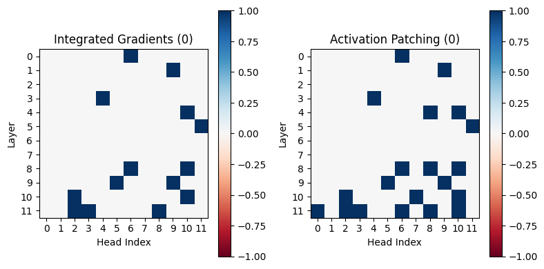

```python
mean_attn_ig = ig_corrupt_clean_attn[0].mean()
std_attn_ig = ig_corrupt_clean_attn[0].std()

ig_significant = ig_corrupt_clean_attn[0].abs() > (mean_attn_ig + std_attn_ig)
ig_attn_indices = ig_significant.nonzero()

mean_attn_ap = ap_corrupt_clean_attn[0].mean()
std_attn_ap = ap_corrupt_clean_attn[0].std()

ap_significant = ap_corrupt_clean_attn[0].abs() > (mean_attn_ap + std_attn_ap)
ap_attn_indices = ap_significant.nonzero()

plot_attn_comparison(ig_significant.unsqueeze(0).int(), ap_significant.unsqueeze(0).int(), Task.IOI, model)
```

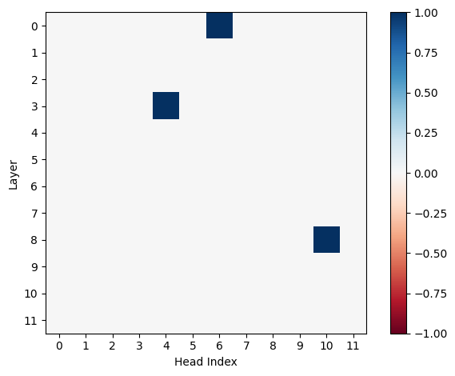

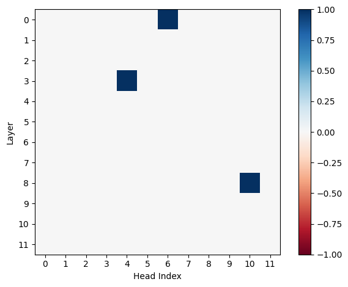

```python
# IG-exclusive components which highlight AND/OR
plot_attn((individual_high_ap_asymmetry & ig_significant).int(), model)
plot_attn((individual_high_ap_asymmetry & ap_significant).int(), model)
```

# Verification of AND/OR circuits in GPT2-small

- Hypothesis: components with high asymmetry are latent (AND/OR circuit) components, which only affect performance if ablated alongside other components.

Here we use an individual example, not the results from the means.

```python
# Baseline performance

logits = model(clean_input)
baseline_performance = logit_diff_metric(logits, labels).mean()

print(f"Mean baseline performance: {baseline_performance}")
```

```
Mean baseline performance: 0.5738016366958618
```

```python
mean_corrupt_activations = dict()
for hook_name, act in corrupted_cache.cache_dict.items():
    mean_corrupt_activations[hook_name] = act.mean(dim=0)
```

```python
ig_indices = ig_significant.nonzero()
# AND components: corrupt->clean detects, clean->corrupt does not detect
and_indices = (ap_attn_asymmetry[0] > 0.25).nonzero()
# OR components: corrupt->clean does not detect, clean->corrupt detects
or_indices = (ap_attn_asymmetry[0] < -0.25).nonzero()
```

```python
def run_with_ablation_attn(model, input, ablation_indices, metric, metric_labels):

    def patch_hook(act, hook, component_idx):
        corrupt_acts = mean_corrupt_activations[hook.name]
        # print(act.shape, corrupt_acts.shape, component_idx)
        act[:, :, component_idx] = corrupt_acts[:, component_idx]
        return act

    hook_tuples = []
    for layer_idx, component_idx in ablation_indices:
        hook_name = get_act_name("result", layer_idx)
        hook_fn = lambda act, hook: patch_hook(act, hook, component_idx)
        hook_tuples.append((hook_name, hook_fn))

    with model.hooks(fwd_hooks=hook_tuples):
        patched_logits = model(input)

    return metric(patched_logits, metric_labels)
```

For OR components, we ablate the component by itself - logit diff should not change. We then ablate all OR components / ablate all significant components / ablate all significant components and OR components, and see how performance drops.

```python
for idx in or_indices:
    print(f"Analysing component {idx}...")
    # Ablate component only
    or_ablated_outputs = run_with_ablation_attn(model, clean_input, [idx], logit_diff_metric, labels)
    or_ablated_performance = or_ablated_outputs.mean()
    print(f"Average logit diff after ablating OR component only: {or_ablated_performance}")

# Ablate all OR components
all_or_ablated_outputs = run_with_ablation_attn(model, clean_input, or_indices, logit_diff_metric, labels)
all_or_ablated_performance = all_or_ablated_outputs.mean()
print(f"Average logit diff after ablating all OR components: {all_or_ablated_performance}")

# Ablate all significant components
ig_ablated_outputs = run_with_ablation_attn(model, clean_input, ig_indices, logit_diff_metric, labels)
ig_ablated_performance = ig_ablated_outputs.mean()
print(f"Average logit diff after ablating IG significant components: {ig_ablated_performance}")

# Ablate both
all_indices = torch.cat([ig_indices, or_indices])
both_ablated_outputs = run_with_ablation_attn(model, clean_input, all_indices, logit_diff_metric, labels)
both_ablated_performance = both_ablated_outputs.mean()
print(f"Average logit diff after ablating both IG significant and OR components: {both_ablated_performance}")
```

```
Analysing component tensor([0, 1])...
Average logit diff after ablating OR component only: 0.5760906934738159
Analysing component tensor([0, 6])...
Average logit diff after ablating OR component only: 0.5822761654853821
Analysing component tensor([2, 9])...
Average logit diff after ablating OR component only: 0.5502066612243652
Analysing component tensor([5, 8])...
Average logit diff after ablating OR component only: 0.5332540273666382
Analysing component tensor([6, 6])...
Average logit diff after ablating OR component only: 0.5817717909812927
Analysing component tensor([6, 9])...
Average logit diff after ablating OR component only: 0.5018073916435242
Analysing component tensor([ 8, 10])...
Average logit diff after ablating OR component only: 0.3803260028362274
Analysing component tensor([9, 6])...
Average logit diff after ablating OR component only: 0.703966498374939
Average logit diff after ablating all OR components: 0.4780121445655823
Average logit diff after ablating IG significant components: 0.5230469107627869
Average logit diff after ablating both IG significant and OR components: 0.44336631894111633
```

```python
for idx in and_indices:
    print(f"Analysing component {idx}...")
    # Ablate component only
    and_ablated_outputs = run_with_ablation_attn(model, clean_input, [idx], logit_diff_metric, labels)
    and_ablated_performance = and_ablated_outputs.mean()
    print(f"Average logit diff after ablating AND component only: {and_ablated_performance}")

# Ablate all AND components
all_and_ablated_outputs = run_with_ablation_attn(model, clean_input, and_indices, logit_diff_metric, labels)
all_and_ablated_performance = all_and_ablated_outputs.mean()
print(f"Average logit diff after ablating all AND components: {all_and_ablated_performance}")

# Ablate all significant components
ig_ablated_outputs = run_with_ablation_attn(model, clean_input, ig_indices, logit_diff_metric, labels)
ig_ablated_performance = ig_ablated_outputs.mean()
print(f"Average logit diff after ablating IG significant components: {ig_ablated_performance}")

# Ablate both
all_indices = torch.cat([ig_indices, and_indices])
both_ablated_outputs = run_with_ablation_attn(model, clean_input, all_indices, logit_diff_metric, labels)
both_ablated_performance = both_ablated_outputs.mean()
print(f"Average logit diff after ablating both IG significant and AND components: {both_ablated_performance}")
```

[output not shown]

# Exclusive components

- Hypothesis: IG-exclusive components are meaningful components which influence model behaviour.
- Method: ablate all components which IG and AP agree on. Ablate all IG components and check performance. Ablate all AP components and check performance. We expect ablating all IG components to decrease performance more than ablating AP components.

```python
mean_attn_ig = avg_ig_corrupt_clean_attn.mean()
std_attn_ig = avg_ig_corrupt_clean_attn.std()

ig_significant = avg_ig_corrupt_clean_attn.abs() > (mean_attn_ig + std_attn_ig)
ig_attn_indices = ig_significant[0].nonzero()
```

```python
mean_attn_ap = avg_ap_corrupt_clean_attn.mean()
std_attn_ap = avg_ap_corrupt_clean_attn.std()

ap_significant = avg_ap_corrupt_clean_attn.abs() > (mean_attn_ap + std_attn_ap)
ap_attn_indices = ap_significant[0].nonzero()
```

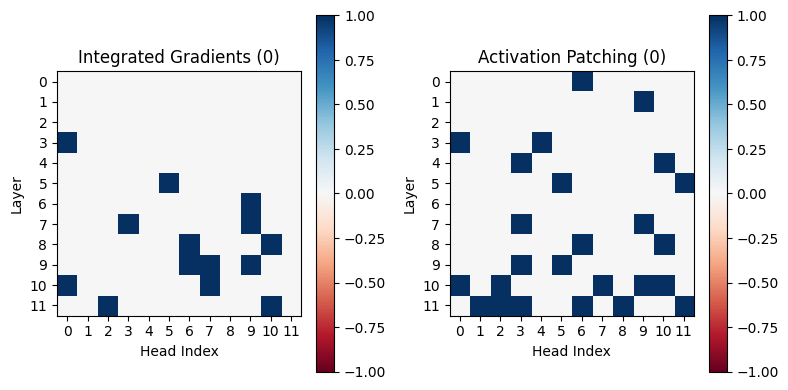

```python
plot_attn_comparison(ig_significant.int(), ap_significant.int(), Task.IOI, model)
```

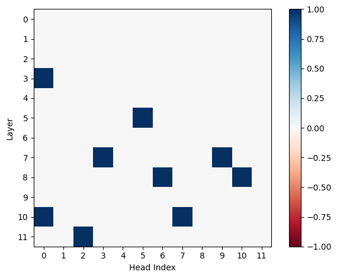

```
Average logit diff after ablating all common components: 0.6847213506698608
```

```python
# Ablate all components which IG and AP agree on
both_attn_significant = ig_significant & ap_significant
both_attn_indices = both_attn_significant[0].nonzero()

plot_attn(both_attn_significant[0].int(), model)

agreed_outputs = run_with_ablation_attn(model, clean_input, both_attn_indices, logit_diff_metric, labels)
agreed_performance = agreed_outputs.mean()

print(f"Average logit diff after ablating all common components: {agreed_performance}")
```

```python
# Ablate all IG components
ig_ablated_outputs = run_with_ablation_attn(model, clean_input, ig_attn_indices, logit_diff_metric, labels)
ig_ablated_performance = ig_ablated_outputs.mean()
print(f"Average logit diff after ablating IG components: {ig_ablated_performance}")

# Ablate all AP components
ap_ablated_outputs = run_with_ablation_attn(model, clean_input, ap_attn_indices, logit_diff_metric, labels)
ap_ablated_performance = ap_ablated_outputs.mean()
print(f"Average logit diff after ablating AP components: {ap_ablated_performance}")
```

```
Average logit diff after ablating IG components: 0.5655986070632935
Average logit diff after ablating AP components: 0.527777373790741
```